# Session 3: principal component analysis

Continuous traits, dimension reduction and interpretation

O Rodriguez de Rivera Ortega, PhD

University of Exeter

# 1 PCA in context

## 1.1 Continuity from previous sessions

In session 1 we visualised several variables using scatterplots, facets and pair plots.

PCA asks a related question:

> Can we replace several correlated continuous variables with a smaller number of synthetic axes that retain most of the variation?

This is not a GLM or GLMM because we are not modelling a single response. PCA is an exploratory dimension-reduction method.

## 1.2 Learning outcomes

By the end of this section, students should be able to:

- explain why PCA requires numeric variables and usually standardisation;
- fit PCA using `prcomp()`;
- interpret scree plots, scores and loadings;
- explain what a biplot shows;
- decide when PCA is useful and when it is not.

# 2 Setup

## 2.1 Packages and data

```r
install.packages(c("tidyverse", "palmerpenguins", "broom", "patchwork"))
```

```r
library(tidyverse)
library(palmerpenguins)
library(broom)
library(patchwork)

theme_set(theme_minimal(base_size = 12))
```

```r
penguins_clean <- penguins %>%
  drop_na(species, island, sex, bill_length_mm, bill_depth_mm,
          flipper_length_mm, body_mass_g) %>%
  mutate(
    species = factor(species),
    island = factor(island),
    sex = factor(sex)
  )

penguin_traits <- penguins_clean %>%
  dplyr::select(bill_length_mm, bill_depth_mm, flipper_length_mm, body_mass_g)
```

# 3 Why PCA?

## 3.1 Four variables, many relationships

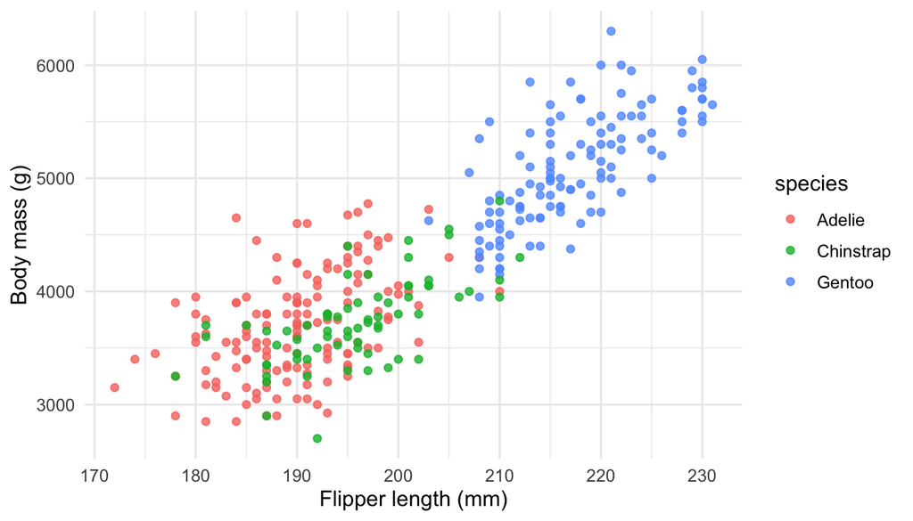

```r
ggplot(penguins_clean, aes(flipper_length_mm, body_mass_g, colour = species)) +
  geom_point(alpha = 0.8) +
  labs(x = "Flipper length (mm)", y = "Body mass (g)")
```

A single scatterplot is useful, but it only shows two variables at a time.

PCA gives us new axes that summarise common patterns across all selected variables.

## 3.2 PCA assumptions in practice

PCA works best when:

- variables are continuous;
- relationships are approximately linear;
- variables are measured on comparable scales, or standardised;
- the aim is exploration or dimension reduction, not causal modelling.

PCA does **not** know about species labels unless we add them later for interpretation.

# 4 Standardisation

## 4.1 Compare variable scales

```r
penguin_traits %>%
  summarise(across(everything(), list(mean = mean, sd = sd, range = ~ max(.x) - min(.x)))) %>%
  pivot_longer(everything(), names_to = "summary", values_to = "value")
```

```
## # A tibble: 12 × 2
##    summary                   value
##    <chr>                     <dbl>
##  1 bill_length_mm_mean       44.0
##  2 bill_length_mm_sd          5.47
##  3 bill_length_mm_range      27.5
##  4 bill_depth_mm_mean        17.2
##  5 bill_depth_mm_sd           1.97
##  6 bill_depth_mm_range        8.4
##  7 flipper_length_mm_mean   201.
##  8 flipper_length_mm_sd      14.0
##  9 flipper_length_mm_range   59
## 10 body_mass_g_mean        4207.
## 11 body_mass_g_sd           805.
## 12 body_mass_g_range       3600
```

Body mass is measured in grams, so it has a much larger numerical scale than bill measurements.

If we do not standardise, body mass can dominate the PCA.

## 4.2 Standardise and run PCA

```r
pca_fit <- prcomp(penguin_traits, center = TRUE, scale. = TRUE)

pca_fit
```

```
## Standard deviations (1, .., p=4):
## [1] 1.6569115 0.8821095 0.6071594 0.3284579
##
## Rotation (n x k) = (4 x 4):
##                          PC1         PC2        PC3        PC4
## bill_length_mm     0.4537532 -0.60019490 -0.6424951  0.1451695
## bill_depth_mm     -0.3990472 -0.79616951  0.4258004 -0.1599044
## flipper_length_mm  0.5768250 -0.00578817  0.2360952 -0.7819837
## body_mass_g        0.5496747 -0.07646366  0.5917374  0.5846861
```

The four original variables have been transformed into four principal components.

Each component is a linear combination of the original variables.

# 5 Variance explained

## 5.1 Scree plot

```r
pca_var <- tibble(
  component = paste0("PC", seq_along(pca_fit$sdev)),
  variance = pca_fit$sdev^2,
  prop_variance = variance / sum(variance),
  cum_variance = cumsum(prop_variance)
)

pca_var
```

```
## # A tibble: 4 × 4
##   component variance prop_variance cum_variance
##   <chr>        <dbl>         <dbl>        <dbl>
## 1 PC1          2.75         0.686         0.686
## 2 PC2          0.778        0.195         0.881
## 3 PC3          0.369        0.0922        0.973
## 4 PC4          0.108        0.0270        1
```

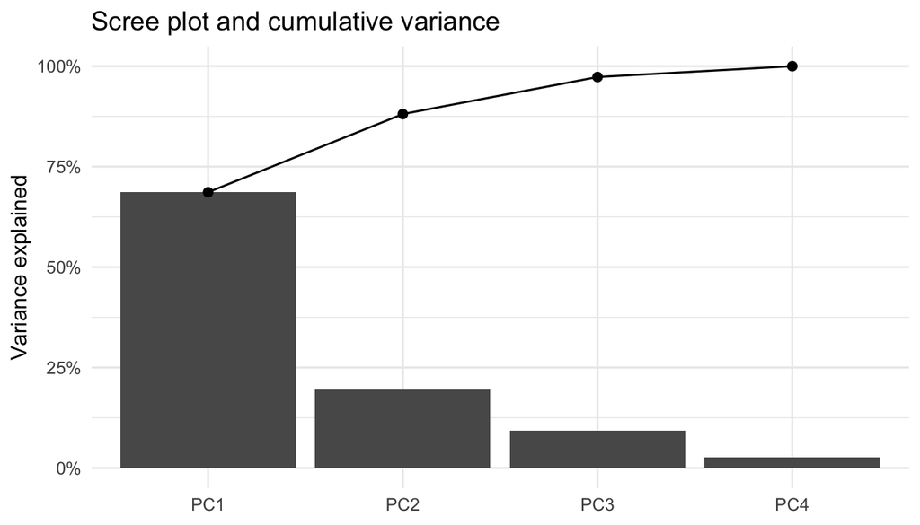

```r
ggplot(pca_var, aes(component, prop_variance)) +
  geom_col() +
  geom_point(aes(y = cum_variance), size = 2) +
  geom_line(aes(y = cum_variance, group = 1)) +
  scale_y_continuous(labels = scales::percent) +
  labs(x = NULL, y = "Variance explained", title = "Scree plot and cumulative variance")
```

## 5.2 Interpretation

The first principal component explains the largest possible amount of variation.

The second principal component explains the largest possible amount of remaining variation, subject to being uncorrelated with PC1.

In teaching, ask:

- How many components are worth interpreting?
- How much information is lost if we retain only two components?
- Is the goal visualisation, interpretation or downstream modelling?

# 6 Scores and loadings

## 6.1 PCA scores

Scores are the coordinates of observations in PCA space.

```r
pca_scores <- as_tibble(pca_fit$x[, 1:2]) %>%
  bind_cols(penguins_clean %>% dplyr::select(species, island, sex))

head(pca_scores)
```

```
## # A tibble: 6 × 5
##     PC1     PC2 species island    sex
##   <dbl>   <dbl> <fct>   <fct>     <fct>
## 1 -1.85 -0.0320 Adelie  Torgersen male
## 2 -1.31  0.443  Adelie  Torgersen female
## 3 -1.37  0.161  Adelie  Torgersen female
## 4 -1.88  0.0123 Adelie  Torgersen female
## 5 -1.92 -0.816  Adelie  Torgersen male
## 6 -1.77  0.366  Adelie  Torgersen female
```

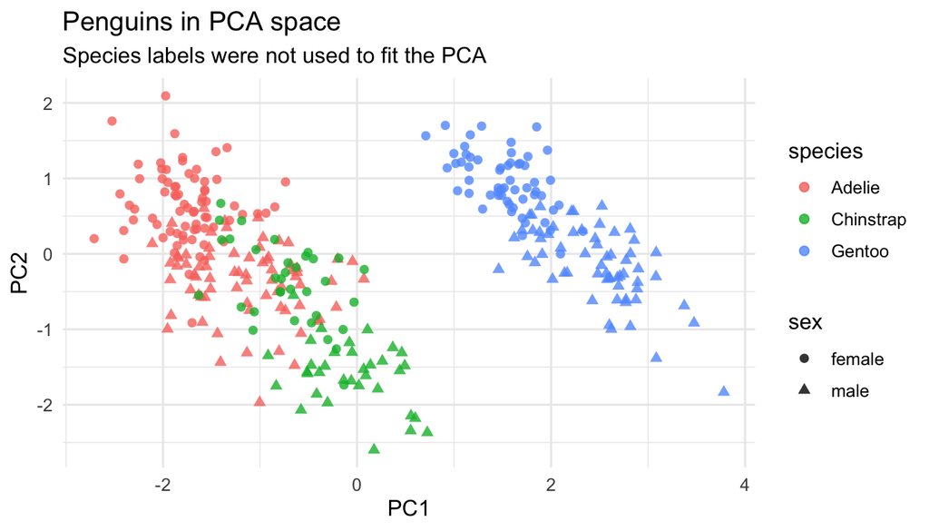

```r
ggplot(pca_scores, aes(PC1, PC2, colour = species, shape = sex)) +
  geom_point(alpha = 0.8, size = 2) +
  labs(
    title = "Penguins in PCA space",
    subtitle = "Species labels were not used to fit the PCA"
  )
```

## 6.2 PCA loadings

Loadings describe how strongly each original variable contributes to each component.

```r
pca_loadings <- as_tibble(pca_fit$rotation[, 1:2], rownames = "trait")

pca_loadings
```

```
## # A tibble: 4 × 3
##   trait                PC1      PC2
##   <chr>              <dbl>    <dbl>
## 1 bill_length_mm     0.454 -0.600
## 2 bill_depth_mm     -0.399 -0.796
## 3 flipper_length_mm  0.577 -0.00579
## 4 body_mass_g        0.550 -0.0765
```

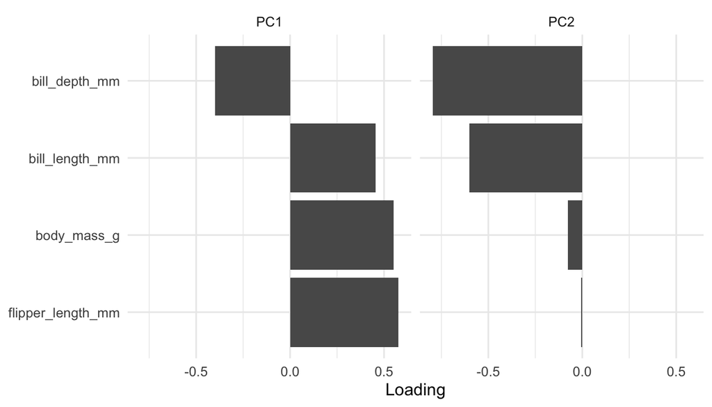

```r
pca_loadings %>%
  pivot_longer(PC1:PC2, names_to = "component", values_to = "loading") %>%
  ggplot(aes(reorder(trait, abs(loading)), loading)) +
  geom_col() +
  coord_flip() +
  facet_wrap(~ component) +
  labs(x = NULL, y = "Loading")
```

## 6.3 A simple biplot

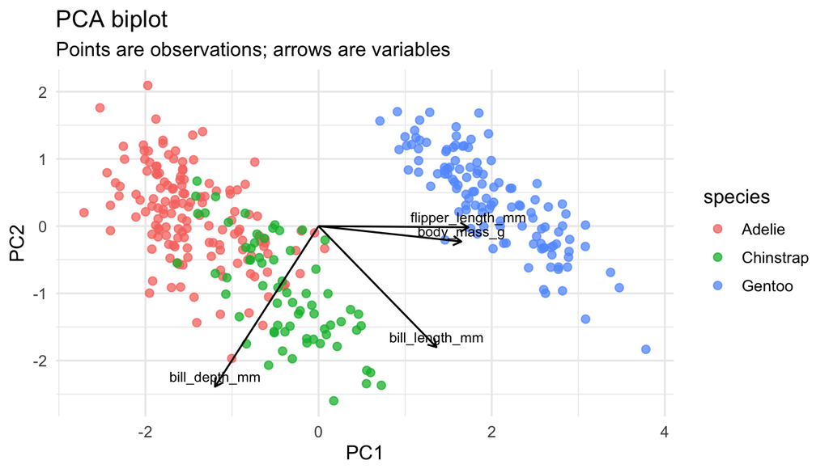

```r
arrow_scale <- 3

loadings_plot <- pca_loadings %>%
  mutate(
    PC1 = PC1 * arrow_scale,
    PC2 = PC2 * arrow_scale
  )

ggplot(pca_scores, aes(PC1, PC2, colour = species)) +
  geom_point(alpha = 0.75, size = 2) +
  geom_segment(
    data = loadings_plot,
    aes(x = 0, y = 0, xend = PC1, yend = PC2),
    inherit.aes = FALSE,
    arrow = arrow(length = unit(0.2, "cm"))
  ) +
  geom_text(
    data = loadings_plot,
    aes(PC1, PC2, label = trait),
    inherit.aes = FALSE,
    nudge_y = 0.15,
    size = 3
  ) +
  labs(title = "PCA biplot", subtitle = "Points are observations; arrows are variables")
```

# 7 Using PCA outputs

## 7.1 PCA as a bridge to later methods

PCA scores can be used in later analysis.

Examples:

- plotting clusters in PC space;
- using PC1 as a body-size index;
- reducing collinearity before regression;
- summarising morphology before classification.

But PCA axes must be interpreted carefully because they are mathematical summaries, not directly observed variables.

## 7.2 Optional: use PC1 in a simple model

This connects back to GLMs.

```r
pc_model_data <- pca_scores %>%
  mutate(is_gentoo = species == "Gentoo")

pc_glm <- glm(is_gentoo ~ PC1 + PC2, data = pc_model_data, family = binomial)

summary(pc_glm)
```

```
##
## Call:
## glm(formula = is_gentoo ~ PC1 + PC2, family = binomial, data = pc_model_data)
##
## Coefficients:
##             Estimate Std. Error z value Pr(>|z|)
## (Intercept)   -19.24   14700.52  -0.001    0.999
## PC1            29.08   13810.22   0.002    0.998
## PC2            14.67   37517.05   0.000    1.000
##
## (Dispersion parameter for binomial family taken to be 1)
##
##     Null deviance: 4.3415e+02  on 332  degrees of freedom
## Residual deviance: 8.3464e-09  on 330  degrees of freedom
## AIC: 6
##
## Number of Fisher Scoring iterations: 25
```

# 8 Practical exercise

## 8.1 Exercise: interpret the PCA

1. Which variables contribute most strongly to PC1?
2. Which variables contribute most strongly to PC2?
3. Which species is most separated along PC1?
4. Would you keep one component, two components or more? Why?
5. Re-run the PCA using only three traits. How do the scores and loadings change?